# PROYECTO FINAL SEGMENTACION DE CORBICULAS

## Miebros del Grupo:

```
- Ramiro Garcia
- Rodrigo Jerez
- Ramiro Suárez Paz
```

# Presentación del dataset, historia de los datos:

El licenciado Leandro A. Hünicken se encuentra trabajando en su tesis doctoral para el Conicet, está actuialmente estudiando la distribución de un bivalvo invasor en el territorio de la República Argentina.

Trabaja en esta temática desde el 2014 y gentilmente nos cedió el uso de los datos para realizar el trabajo final del curso DATA SCIENCE de CoderHouse

Los datos son relevados por él mismo en distintas puntos de Argentina dónde se detecta la presencia de este bivalvo.

La importancia de este estudio radica en que la Almeja Asiática (corbícula spp.) genera impactos negativos en los ambientes en los que es introducida.

Existe la posibilidad de qué nos envíe nuevos registros durante la cursada que permitirían evaluar el desempeño de nuestro modelo con nuevos datos.

# El estudio registra la presencia de corbícula en distintas provincias de Argentina

La corbicula es un género de moluscos bivalvos generalmente encontrada en aguas dulces, Los moluscos y crustáceos son importantes en la transferencia energética a niveles tróficos superiores, se mediran 2 linajes: largillierti y fluminea, existen ,muestras que por no cumplir con los parametros se indentificaron como un linaje "Indeterminado"

# Data Acquisition

## Librerias a Importar

```python
#Pandas
import pandas as pd
#import pandas_profiling

#Numpy
import numpy as np

#from sklearn import tree
#from sklearn import datasets, linear_model
from sklearn.model_selection import train_test_split
#from sklearn.model_selection import KFold
#from sklearn.cross_validation import KFold
#from sklearn.linear_model import LinearRegression
from sklearn.linear_model import LogisticRegression
from sklearn.tree import DecisionTreeClassifier
from sklearn.ensemble import RandomForestClassifier
from sklearn.neighbors import KNeighborsClassifier
#from sklearn.neighbors import KNeighborsRegressor

#AdaBoost
from sklearn.ensemble import AdaBoostClassifier

#Métricas:
from sklearn.metrics import confusion_matrix
from sklearn.metrics import plot_confusion_matrix
from sklearn.metrics import accuracy_score
from sklearn.metrics import precision_score
from sklearn.metrics import recall_score
from sklearn.metrics import f1_score
#from sklearn.metrics import classification_report

#curva roc
from sklearn.metrics import roc_curve, auc

#regresión
#from sklearn.metrics import r2_score
#from sklearn import metrics

#Kmeans
#from sklearn.cluster import KMeans

#grid search
from sklearn.model_selection import GridSearchCV

#from sklearn.tree import DecisionTreeRegressor
#from sklearn.model_selection import StratifiedKFold

#import matplotlib as mpl
import matplotlib.pyplot as plt
#from matplotlib.ticker import FormatStrFormatter
%matplotlib inline

import seaborn as sns
#from seaborn import distplot
from seaborn import boxplot
from seaborn import violinplot

#import missingno as msno

#import plotly.express as px

#from openpyxl import workbook
#from openpyxl import load_workbook


import warnings
warnings.simplefilter("ignore")

print ("Pandas Version:", pd.__version__)
```

```
Pandas Version: 1.3.4
```

```python
#Lectura desde Jupyter Notebook
proy = pd.read_excel('estudio_corbicula spp_dep.xlsx', sheet_name='Tabla A3.1')
```

```python
# Descripcion de Variables

# ID individuo                 : Codigo Nemotecnico que indentifica a cada individuo de la muestra
# Código población             : Codigo de Clusterización que agrupa la poblacion de la muestra
# Linaje                       : Linaje identificado de acuerdo a las caracteristicas morfolojicas de cada individuo
# V_VLargo (mm)                : Identifica el valor numerico del largo de la Valva por cada individuo
# V_Alto (mm)                  : Identifica el valor numerico del Alto de la Valva por cada individuo
# V_Ancho (mm)                 : Identifica el valor numerico del Ancho de la Valva por cada individuo
# Peso (g)                     : Indica el peso de cada individuo registrado en la muestra
# Área branquial (mm2)         : Registra la medicion del area branquial de cada individuo
# Área de palpos (mm2)         : Registra la medicion del area de palpos o labios por cada individuo estudiado
# Densidad de filamentos mm-1  : Identifica la magnitud en cantidad de filamentos que posee cada individuo
```

# Analisis de los componentes principales

Variables categoricas a3.1: Linaje -largillierti -fluminea -indeterminado

```python
proy #es el total de los datos
```

|  | ID individuo | Codigo poblacion | Linaje | V_Largo | V_alto | V_ancho | Peso | Area_branquial | Area de palpos | Densidad de filamentos |
| --- | --- | --- | --- | --- | --- | --- | --- | --- | --- | --- |
| 0 | APO1 | APO | indeterminado | 24.470000 | 21.37 | 13.29 | 1.6644 | 356.392456 | 32.183664 | 22.872956 |
| 1 | APO2 | APO | indeterminado | 13.080000 | 11.56 | 8.32 | 0.4309 | 104.126102 | 17.147800 | 26.033772 |
| 2 | APO3 | APO | indeterminado | 21.560000 | 19.00 | 14.21 | 2.2802 | 241.675815 | 34.895924 | 26.855919 |
| 3 | APO4 | APO | indeterminado | 22.980000 | 21.27 | 15.21 | 2.6219 | 279.278332 | 51.996126 | 24.398761 |
| 4 | APO5 | APO | indeterminado | 13.720000 | 11.95 | 8.70 | 0.4440 | 107.539830 | 10.698527 | 24.166084 |
| ... | ... | ... | ... | ... | ... | ... | ... | ... | ... | ... |
| 294 | BA26 | BA | fluminea | 13.086667 | 12.14 | 9.12 | 0.6460 | 66.017891 | 11.059626 | 27.166501 |
| 295 | BA27 | BA | fluminea | 15.193333 | 14.19 | 10.44 | 0.9949 | 103.584686 | 16.028288 | 27.039393 |
| 296 | BA28 | BA | fluminea | 14.840000 | 13.56 | 10.04 | 0.8666 | 83.954159 | 12.526340 | 24.483844 |
| 297 | BA29 | BA | fluminea | 16.106667 | 15.17 | 11.14 | 1.1449 | 106.638271 | 17.432224 | 27.254977 |
| 298 | BA30 | BA | fluminea | 14.893333 | 13.72 | 10.04 | 0.9040 | 94.517853 | 12.559382 | 27.417736 |

299 rows × 10 columns

```python
#el shape del proyecto contiene (calntidad de filas 299 por 10 columnas)
proy.shape
```

```
(299, 10)
```

```python
#Tipos de datos
proy.dtypes
```

```
ID individuo                object
Codigo poblacion            object
Linaje                      object
V_Largo                    float64
V_alto                     float64
V_ancho                    float64
Peso                       float64
Area_branquial             float64
Area de palpos             float64
Densidad de filamentos     float64
dtype: object
```

```python
#Revisamos el tipo de datos
proy.info()
```

```
<class 'pandas.core.frame.DataFrame'>
RangeIndex: 299 entries, 0 to 298
Data columns (total 10 columns):
 #   Column                   Non-Null Count  Dtype
---  ------                   --------------  -----
 0   ID individuo             299 non-null    object
 1   Codigo poblacion         299 non-null    object
 2   Linaje                   299 non-null    object
 3   V_Largo                  299 non-null    float64
 4   V_alto                   299 non-null    float64
 5   V_ancho                  299 non-null    float64
 6   Peso                     299 non-null    float64
 7   Area_branquial           298 non-null    float64
 8   Area de palpos           298 non-null    float64
 9   Densidad de filamentos   298 non-null    float64
dtypes: float64(7), object(3)
memory usage: 23.5+ KB
```

```python
#Revisamos el resumen estadistico de cada variable
proy.describe().T
```

|  | count | mean | std | min | 25% | 50% | 75% | max |
| --- | --- | --- | --- | --- | --- | --- | --- | --- |
| V_Largo | 299.0 | 17.034365 | 3.528919 | 9.170000 | 14.257500 | 16.860000 | 19.395000 | 29.770000 |
| V_alto | 299.0 | 15.391538 | 3.235356 | 8.300000 | 13.025000 | 15.170000 | 17.695000 | 25.920000 |
| V_ancho | 299.0 | 10.308395 | 2.277442 | 5.830000 | 8.830000 | 9.920000 | 11.530000 | 17.240000 |
| Peso | 299.0 | 1.048102 | 0.799853 | 0.129600 | 0.516750 | 0.795200 | 1.335600 | 5.252600 |
| Area_branquial | 298.0 | 128.554558 | 60.384128 | 31.568504 | 84.897855 | 117.360736 | 151.809406 | 381.418457 |
| Area de palpos | 298.0 | 19.197241 | 9.783902 | 5.843648 | 12.247395 | 16.861913 | 22.874433 | 65.484017 |
| Densidad de filamentos | 298.0 | 27.785284 | 4.136318 | 19.240707 | 24.817258 | 27.258851 | 30.165574 | 43.689214 |

```python
cantidades = proy["Linaje"].value_counts().to_frame()

cantidades
```

|  | Linaje |
| --- | --- |
| largillierti | 124 |
| fluminea | 90 |
| indeterminado | 85 |

```python
## Declaramos valores para el eje x
eje_x = cantidades.index

## Declaramos valores para el eje y
eje_y = cantidades.Linaje
```

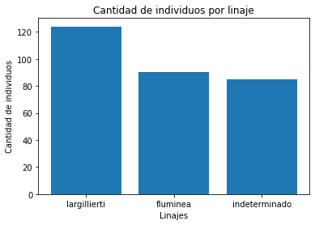

```python
plt.figure()    #Figura. Puede incluirse el tamaño con figsize
plt.bar(eje_x, eje_y)          #El gráfico
plt.title('Cantidad de individuos por linaje')      #El título
ax = plt.subplot()                   #Axis
ax.set_xticks(eje_x)             #Eje x
ax.set_xticklabels(eje_x)        #Etiquetas del eje x
ax.set_xlabel('Linajes')  #Nombre del eje x
ax.set_ylabel('Cantidad de individuos')  #Nombre del eje y
```

Con este gráfico se concluye que entre los linajes largillierti y fluminea, en principio, no hay un desbalance considerable.

```python
# cuales son los principales medidas estadisticas de nuestra candidata a variable objetivo
proy.Peso.describe()
```

```
count    299.000000
mean       1.048102
std        0.799853
min        0.129600
25%        0.516750
50%        0.795200
75%        1.335600
max        5.252600
Name: Peso, dtype: float64
```

# Análisis univariado: Parámetro Peso

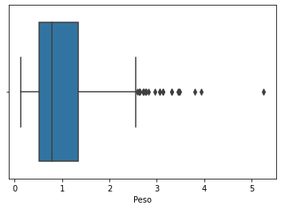

```python
boxplot(proy.Peso, orient="v")
```

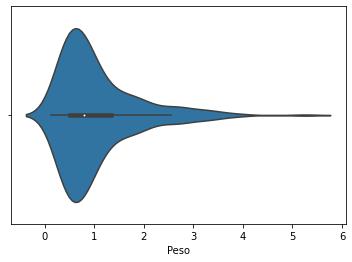

```python
violinplot(proy.Peso, data=proy , orient="v")
```

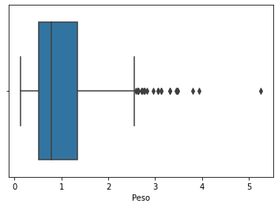

```python
boxplot(proy.Peso, orient="v")
```

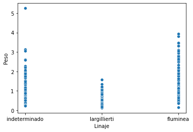

```python
sns.scatterplot(proy['Linaje'], proy['Peso'])
```

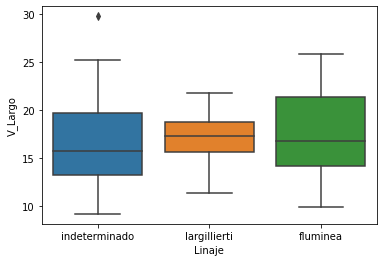

```python
sns.boxplot(x=proy['Linaje'], y=proy['V_Largo'])
```

Se observa que existe un impacto acotado en el largo de los especimenes principalmente en "largillierti" que registra una diferencia entre las medianas mayor que el resto de los linajes

# Analisis Multivariado

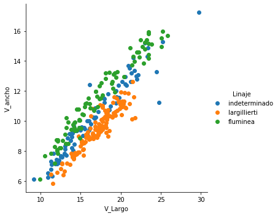

```python
sns.FacetGrid(proy,hue = 'Linaje' , size = 5).map(plt.scatter,'V_Largo','V_ancho').add_legend();
plt.show()
```

Podemos distinguir en primera instancia que el ancho de la valva podria determinar el tipo de linaje de la corbicula siendo las mas anchas las "fluminea". Y a priori los indeterminados no pueden ser clasificados como uno u otro linaje por encontrarse con características que podrían ser de ambos.

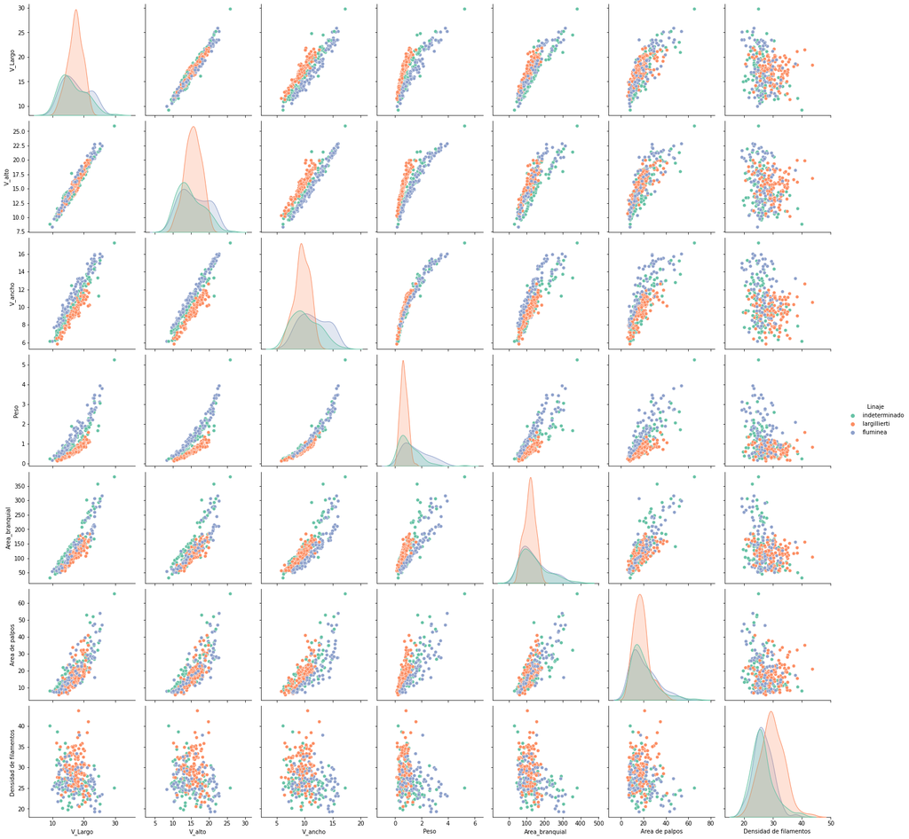

```python
sns.pairplot(proy,hue = 'Linaje' , size = 3 , palette = 'Set2')
```

### Conclusiones

- El Grafico nos muestra que el Largo, Ancho y Alto de las valvas en conjunto con el peso (variables cuantitativas) son depedientes entre si y homogeneas por lo tanto podemos concluir que existe una regresion lineal positiva en las variables indicadas
- Podemos definir que la combinacion entre variables "Peso" y "Area Branquial" podria servir para realizar un predicción dada la dispersion de las obsevaciones
- La variable V_alto podria servir para predecir el linaje lagillierti por su grado de dispersion, para predecir las otras varibles podemos incluir V_largo
- si combinamos las variables V_alto,V_ancho,V_largo y Peso , podemos encontrar una buena combinacion para identificar un predictor para todos los linajes
- Respecto a la varible densidad de filamentos podemos ver que los linajes fluminea indeterminado presentan poca separacion entre las obervaciones para poder prodecir la variables objetivo, sin embargo es eficiente para predecir el linaje lagillierti

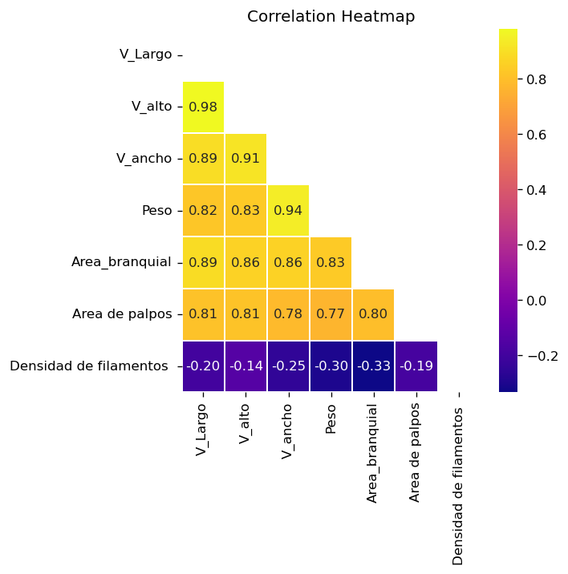

```python
plt.figure(dpi = 120,figsize= (5,5))
mask = np.triu(np.ones_like(proy.corr(),dtype = bool))
sns.heatmap(proy.corr(),mask = mask, fmt = ".2f",annot=True,lw=1,cmap = 'plasma')
plt.yticks(rotation = 0)
plt.xticks(rotation = 90)
plt.title('Correlation Heatmap')
plt.show()
```

Este grafico nos muestra que existe una alta correlacion en gran parte de las variables del proyecto con excepcion de la variable "densidad de filamentos". Esto tiene sentido porque la mayoría de las variables tienen que ver con el tamaño de cada individuo (peso, largo, ancho, etc.) y la densidad de filamentos no. Sin perjuicio que existe alta correlacion en gran parte de las variables podemos distinguir que la variables "Peso", "Area Branquial" y "Densidad de Filamentos" pueden ser candidatas para ser usadas como varibles predictoras para no tener un problema de multicolinealidad, tambien podrian ser usada la combinacion "Peso" y "Area de Palpo". De todas maneras por ser "pocas" variables a analizar vamos a considerarlas a todas en lo sucesivo.

# Chequeo de cuatro modelos de ML supervizado

```python
# Eliminamos el registro con faltante
proysinindet = proy[proy['Linaje'] != 'indeterminado'] #todos los datos que no son indeterminados
data = proysinindet.dropna() #los datos que nos son indeterminados sin el registro con un parámetro faltante
```

```python
# Dividimos entre los parámetros y la variable a definir (sacando los campos que no se consideran)

x_chequeo = data.drop(['ID individuo', 'Codigo poblacion', 'Linaje'],1)
y_chequeo = data.Linaje
```

```python
x_chequeo
```

|  | V_Largo | V_alto | V_ancho | Peso | Area_branquial | Area de palpos | Densidad de filamentos |
| --- | --- | --- | --- | --- | --- | --- | --- |
| 30 | 17.380000 | 16.36 | 11.09 | 0.8298 | 136.409557 | 29.320977 | 35.210798 |
| 31 | 18.420000 | 17.15 | 10.73 | 0.8422 | 133.760063 | 22.367643 | 29.218093 |
| 32 | 20.390000 | 19.45 | 11.33 | 0.8611 | 171.941321 | 30.504550 | 28.217912 |
| 33 | 19.480000 | 18.60 | 11.52 | 0.9445 | 151.316416 | 31.233400 | 35.770346 |
| 34 | 19.190000 | 18.41 | 11.61 | 1.0441 | 158.172306 | 32.115102 | 28.338478 |
| ... | ... | ... | ... | ... | ... | ... | ... |
| 294 | 13.086667 | 12.14 | 9.12 | 0.6460 | 66.017891 | 11.059626 | 27.166501 |
| 295 | 15.193333 | 14.19 | 10.44 | 0.9949 | 103.584686 | 16.028288 | 27.039393 |
| 296 | 14.840000 | 13.56 | 10.04 | 0.8666 | 83.954159 | 12.526340 | 24.483844 |
| 297 | 16.106667 | 15.17 | 11.14 | 1.1449 | 106.638271 | 17.432224 | 27.254977 |
| 298 | 14.893333 | 13.72 | 10.04 | 0.9040 | 94.517853 | 12.559382 | 27.417736 |

213 rows × 7 columns

```python
#Cantidad de registros a usar:

print('Quedaron',len(y_chequeo), 'registros.')
```

```
Quedaron 213 registros.
```

```python
# Dividimos entre test y entrenamiento

xtrain, xtest, ytrain, ytest = train_test_split(x_chequeo, y_chequeo, test_size=0.2, random_state=42)
```

```python
# Listado de modelos a probar

lr = LogisticRegression(random_state=42)
lr2 = LogisticRegression(solver='liblinear', random_state=42)
lr3 = LogisticRegression(solver='saga', random_state=42)
dtc = DecisionTreeClassifier(random_state=42)
rfc = RandomForestClassifier(random_state=42)
knn = KNeighborsClassifier()
```

```python
# Iteramos para cada modelo (Enviado en la 2da entrega)

li = [lr,lr2, lr3, dtc,rfc,knn]
d = {}
for i in li:
    i.fit(xtrain,ytrain)
    ypred = i.predict(xtest)
    print(i,":",accuracy_score(ypred,ytest)*100)
    d.update({str(i):i.score(xtest,ytest)*100})
```

```
LogisticRegression(random_state=42) : 100.0
LogisticRegression(random_state=42, solver='liblinear') : 100.0
LogisticRegression(random_state=42, solver='saga') : 65.11627906976744
DecisionTreeClassifier(random_state=42) : 90.69767441860465
RandomForestClassifier(random_state=42) : 90.69767441860465
KNeighborsClassifier() : 69.76744186046511
```

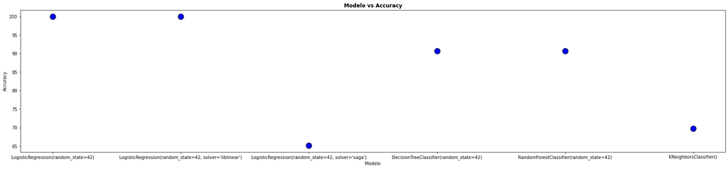

```python
#Graficamos los distintos accuracy para cada modelo.

plt.figure(figsize=(29, 6))
plt.title("Modelo vs Accuracy", fontweight='bold')
plt.xlabel("Modelo")
plt.ylabel("Accuracy")
plt.plot(d.keys(),d.values(),marker='o',color='mediumpurple',linewidth=0,markersize=13,
         markerfacecolor='blue',markeredgecolor='black')
plt.show()
```

### Conclusión

De la regresión logística se obtuvo una precisión de nuestro modelo de 65% con el solver “saga” (aplicandole una penalidad). Sin solver nos arroga una precision del 100% y con el solver “liblinear” nos arroja una precision de 100% Descartamos este último modelo por considerar que al obtener 100% de accuracy es probable que esté overfiteado. Según el accuracy dado para cada uno de los modelos probados decidimos utilizar el Random Forest. Esta decisión se base en que junto con el Decision Tree son los modelos que más accuracy obtienen pero el Random Forest es más robusto.

```python
#Redefinimos X e y
X = x_chequeo.to_numpy()
y = y_chequeo.to_numpy()
```

# Optimizacion del modelo seleccionado

## Hiperparámetros del Random Forest

## GridSearchCV

```python
#Definicion de Hyperparámetros
param_grid = {
    'n_estimators': [200,300,400, 500],
    'max_features': ['auto', 'sqrt', 'log2'],
    'max_depth' : [4,5,6,7,8],
    'criterion' :['gini', 'entropy']
}
```

```python
#Utilizamos la grilla definida anteriormente para rfc
CV_rfc = GridSearchCV(estimator=rfc, param_grid=param_grid, cv= 5)
```

```python
#Entrenamos nuestro modelo de Rfc con la grilla ya definida y CV con tamaño de Fold=5
CV_rfc.fit(xtrain, ytrain)
```

```
GridSearchCV(cv=5, estimator=RandomForestClassifier(random_state=42),
             param_grid={'criterion': ['gini', 'entropy'],
                         'max_depth': [4, 5, 6, 7, 8],
                         'max_features': ['auto', 'sqrt', 'log2'],
                         'n_estimators': [200, 300, 400, 500]})
```

```python
print("Mejores parametros: "+str(CV_rfc.best_params_))
print("Mejor Score: "+str(CV_rfc.best_score_)+'\n')
```

```
Mejores parametros: {'criterion': 'gini', 'max_depth': 7, 'max_features': 'auto', 'n_estimators': 200}
Mejor Score: 0.9588235294117646
```

```python
scores = pd.DataFrame(CV_rfc.cv_results_)
scores
```

|  | mean_fit_time | std_fit_time | mean_score_time | std_score_time | param_criterion | param_max_depth | param_max_features | param_n_estimators | params | split0_test_score | split1_test_score | split2_test_score | split3_test_score | split4_test_score | mean_test_score | std_test_score | rank_test_score |
| --- | --- | --- | --- | --- | --- | --- | --- | --- | --- | --- | --- | --- | --- | --- | --- | --- | --- |
| 0 | 0.245052 | 0.013693 | 0.013899 | 3.444148e-03 | gini | 4 | auto | 200 | {'criterion': 'gini', 'max_depth': 4, 'max_fea... | 0.882353 | 0.970588 | 0.970588 | 0.970588 | 0.911765 | 0.941176 | 0.037203 | 85 |
| 1 | 0.340546 | 0.011700 | 0.030260 | 1.965618e-03 | gini | 4 | auto | 300 | {'criterion': 'gini', 'max_depth': 4, 'max_fea... | 0.882353 | 0.970588 | 0.970588 | 0.941176 | 0.911765 | 0.935294 | 0.034300 | 100 |
| 2 | 0.454268 | 0.002481 | 0.037484 | 7.658440e-03 | gini | 4 | auto | 400 | {'criterion': 'gini', 'max_depth': 4, 'max_fea... | 0.882353 | 0.941176 | 0.970588 | 0.941176 | 0.911765 | 0.929412 | 0.029994 | 109 |
| 3 | 0.618616 | 0.069575 | 0.049978 | 6.236674e-03 | gini | 4 | auto | 500 | {'criterion': 'gini', 'max_depth': 4, 'max_fea... | 0.882353 | 0.941176 | 0.941176 | 0.941176 | 0.911765 | 0.923529 | 0.023529 | 118 |
| 4 | 0.234329 | 0.009881 | 0.015612 | 1.455408e-05 | gini | 4 | sqrt | 200 | {'criterion': 'gini', 'max_depth': 4, 'max_fea... | 0.882353 | 0.970588 | 0.970588 | 0.970588 | 0.911765 | 0.941176 | 0.037203 | 85 |
| ... | ... | ... | ... | ... | ... | ... | ... | ... | ... | ... | ... | ... | ... | ... | ... | ... | ... |
| 115 | 0.602992 | 0.015933 | 0.046862 | 4.422006e-07 | entropy | 8 | sqrt | 500 | {'criterion': 'entropy', 'max_depth': 8, 'max_... | 0.911765 | 0.970588 | 0.941176 | 0.970588 | 0.970588 | 0.952941 | 0.023529 | 13 |
| 116 | 0.237436 | 0.006252 | 0.018747 | 6.248188e-03 | entropy | 8 | log2 | 200 | {'criterion': 'entropy', 'max_depth': 8, 'max_... | 0.941176 | 0.970588 | 0.941176 | 0.970588 | 0.970588 | 0.958824 | 0.014409 | 1 |
| 117 | 0.362425 | 0.011701 | 0.043741 | 3.335852e-02 | entropy | 8 | log2 | 300 | {'criterion': 'entropy', 'max_depth': 8, 'max_... | 0.911765 | 0.970588 | 0.941176 | 0.970588 | 0.970588 | 0.952941 | 0.023529 | 13 |
| 118 | 0.471756 | 0.006279 | 0.031241 | 1.683174e-06 | entropy | 8 | log2 | 400 | {'criterion': 'entropy', 'max_depth': 8, 'max_... | 0.911765 | 0.970588 | 0.941176 | 0.970588 | 0.970588 | 0.952941 | 0.023529 | 13 |
| 119 | 0.631110 | 0.032156 | 0.049989 | 1.169008e-02 | entropy | 8 | log2 | 500 | {'criterion': 'entropy', 'max_depth': 8, 'max_... | 0.911765 | 0.970588 | 0.941176 | 0.970588 | 0.970588 | 0.952941 | 0.023529 | 13 |

120 rows × 17 columns

## Ada boost

```python
#Implementamos el algoritmo de AdaBoost creando un AdaBoostClassifier
ada = AdaBoostClassifier(n_estimators=50,learning_rate=1, random_state=42)
```

```python
#Fiteamos el modelo
model_ada = ada.fit(xtrain, ytrain)
```

```python
#Predicción!
test_pred_ada = model_ada.predict(xtest)
```

```python
test_accuracy_ada = accuracy_score(ytest,  test_pred_ada)

print('% de aciertos sobre el set de evaluación:',test_accuracy_ada)
```

```
% de aciertos sobre el set de evaluación: 0.9767441860465116
```

```python
#renombramos el modelo seleccionado con los mejores parámetros encontrados
model = CV_rfc
```

# Métricas finales

```python
test_pred = model.predict(xtest) #Prediccion en Test
```

## Matriz de confusión

**Recordemos**

Hay cuatro términos importantes en una matriz de confusión:

- Verdaderos positivos (TP): estos son los casos en los que el "Sí" predicho en realidad pertenecía a la clase "Sí".
- Negativos verdaderos (TN): Estos son los casos en los que el “No” predicho en realidad pertenecía a la clase “No”.
- Falsos positivos (FP): estos son los casos en los que el "Sí" predicho en realidad pertenecía a la clase "No".
- Falsos negativos (FN): estos son los casos en los que el "No" predicho en realidad pertenecía a la clase "Sí".

```python
# Matriz de Confusion
cm = confusion_matrix(ytest,  test_pred)
print("Matriz de confusión:")
print(cm)
```

```
Matriz de confusión:
[[20  1]
 [ 3 19]]
```

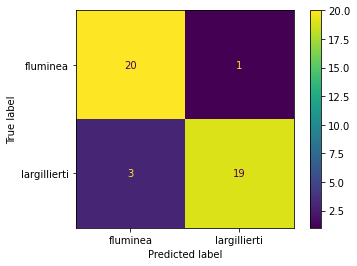

```python
#Ploteamos la Matriz
plot_confusion_matrix(model, xtest, ytest)
plt.show()
```

## Precisión

La precisión es la proporción de verdaderos positivos (TP) por la suma de verdaderos positivos (TP) y falsos positivos (FP).

```python
print(f"Precisión para reconocer fluminea: {precision_score(ytest, test_pred, pos_label='fluminea')}")
print(f"Precisión para reconocer largillierti: {precision_score(ytest, test_pred, pos_label='largillierti')}")
```

```
Precisión para reconocer fluminea: 0.8695652173913043
Precisión para reconocer largillierti: 0.95
```

## Recall

El Recall es la proporción de verdaderos positivos (TP) por la suma de verdaderos positivos (TP) y falsos negativos (FN).

```python
print(f"Recall Score para fluminea: {recall_score(ytest, test_pred, pos_label='fluminea')}")
print(f"Recall Score para largillierti: {recall_score(ytest, test_pred, pos_label='largillierti')}")
```

```
Recall Score para fluminea: 0.9523809523809523
Recall Score para largillierti: 0.8636363636363636
```

## F1 Score

La puntuación F1 es la media armónica de precisión y el recall. Se encuentra entre [0,1].

```python
print(f"F1 Score para fluminea: {f1_score(ytest, test_pred, pos_label='fluminea')}")
print(f"F1 Score para largillierti: {f1_score(ytest, test_pred, pos_label='largillierti')}")
```

```
F1 Score para fluminea: 0.909090909090909
F1 Score para largillierti: 0.9047619047619048
```

## Curva ROC

La curva AUC-ROC es una métrica de rendimiento que se utiliza para medir el rendimiento del modelo de clasificación en diferentes valores de umbral. Cuanto mayor sea el valor de AUC (Área bajo la curva), mejor será nuestro clasificador para predecir las clases. AUC-ROC se utiliza principalmente en problemas de clasificación binaria.

La curva ROC se traza entre la tasa de verdaderos positivos (TPR) y la tasa de falsos positivos (FPR), es decir, TPR en el eje y y FPR en el eje y. AUC es el área bajo la curva ROC.

Un clasificador excelente tiene un valor AUC cercano a 1, mientras que un clasificador de bajo rendimiento tiene un valor AOC cercano a 0. Un clasificador con una puntuación AOC de 0.5 no tiene ninguna capacidad de separación de clases.

```
AUC es: 0.9805194805194805
```

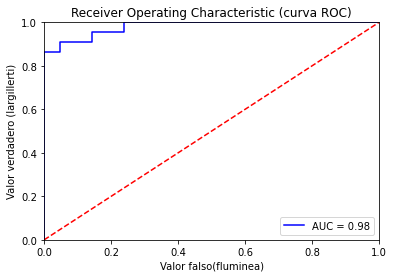

```python
#Curva ROC evaluando largillerti como valor verdadero
class_probabilities = model.predict_proba(xtest)
preds = class_probabilities[:, 1]

fpr, tpr, threshold = roc_curve(ytest, preds, pos_label='largillierti')
roc_auc = auc(fpr, tpr)

# AUC
print(f"AUC es: {roc_auc}")

# Gráfica de la Curva ROC
plt.title('Receiver Operating Characteristic (curva ROC)')
plt.plot(fpr, tpr, 'b', label = 'AUC = %0.2f' % roc_auc)
plt.legend(loc = 'lower right')
plt.plot([0, 1], [0, 1],'r--')
plt.xlim([0, 1])
plt.ylim([0, 1])
plt.ylabel('Valor verdadero (largillerti)')
plt.xlabel('Valor falso(fluminea)')
plt.show()
```

# Entrega a cliente

## Uso del modelo para predecir el linaje de los indeterminados

```python
#nos quedamos con los indeterminados
indeterminados = proy[proy['Linaje'] == 'indeterminado']
```

```python
#nos quedamos con los parámetros de determinados
x_adeterminar = indeterminados.drop(['ID individuo', 'Codigo poblacion', 'Linaje'],1)
```

```python
x_adeterminar
```

|  | V_Largo | V_alto | V_ancho | Peso | Area_branquial | Area de palpos | Densidad de filamentos |
| --- | --- | --- | --- | --- | --- | --- | --- |
| 0 | 24.47 | 21.37 | 13.29 | 1.6644 | 356.392456 | 32.183664 | 22.872956 |
| 1 | 13.08 | 11.56 | 8.32 | 0.4309 | 104.126102 | 17.147800 | 26.033772 |
| 2 | 21.56 | 19.00 | 14.21 | 2.2802 | 241.675815 | 34.895924 | 26.855919 |
| 3 | 22.98 | 21.27 | 15.21 | 2.6219 | 279.278332 | 51.996126 | 24.398761 |
| 4 | 13.72 | 11.95 | 8.70 | 0.4440 | 107.539830 | 10.698527 | 24.166084 |
| ... | ... | ... | ... | ... | ... | ... | ... |
| 142 | 13.62 | 13.76 | 9.15 | 0.8002 | 75.162738 | 14.334908 | 31.513708 |
| 143 | 13.98 | 13.84 | 9.27 | 0.8546 | 71.531984 | 11.237750 | 33.381449 |
| 144 | 11.56 | 11.51 | 7.85 | 0.5033 | 49.835449 | 10.527963 | 38.580331 |
| 145 | 14.10 | 13.81 | 9.66 | 0.8860 | 77.532193 | 18.196331 | 35.827725 |
| 149 | 9.17 | 8.80 | 6.13 | 0.2357 | 31.568504 | 8.140685 | 40.021137 |

85 rows × 7 columns

```python
#predecimos
y_determinada = model.predict(x_adeterminar)
```

```python
#agregamos en el dataframe el resultado predicho
indeterminados["Linaje"] = y_determinada
```

```python
indeterminados
```

|  | ID individuo | Codigo poblacion | Linaje | V_Largo | V_alto | V_ancho | Peso | Area_branquial | Area de palpos | Densidad de filamentos |
| --- | --- | --- | --- | --- | --- | --- | --- | --- | --- | --- |
| 0 | APO1 | APO | fluminea | 24.47 | 21.37 | 13.29 | 1.6644 | 356.392456 | 32.183664 | 22.872956 |
| 1 | APO2 | APO | fluminea | 13.08 | 11.56 | 8.32 | 0.4309 | 104.126102 | 17.147800 | 26.033772 |
| 2 | APO3 | APO | fluminea | 21.56 | 19.00 | 14.21 | 2.2802 | 241.675815 | 34.895924 | 26.855919 |
| 3 | APO4 | APO | fluminea | 22.98 | 21.27 | 15.21 | 2.6219 | 279.278332 | 51.996126 | 24.398761 |
| 4 | APO5 | APO | fluminea | 13.72 | 11.95 | 8.70 | 0.4440 | 107.539830 | 10.698527 | 24.166084 |
| ... | ... | ... | ... | ... | ... | ... | ... | ... | ... | ... |
| 142 | SDE12 | SDEi | fluminea | 13.62 | 13.76 | 9.15 | 0.8002 | 75.162738 | 14.334908 | 31.513708 |
| 143 | SDE23 | SDEi | fluminea | 13.98 | 13.84 | 9.27 | 0.8546 | 71.531984 | 11.237750 | 33.381449 |
| 144 | SDE24 | SDEi | largillierti | 11.56 | 11.51 | 7.85 | 0.5033 | 49.835449 | 10.527963 | 38.580331 |
| 145 | SDE25 | SDEi | fluminea | 14.10 | 13.81 | 9.66 | 0.8860 | 77.532193 | 18.196331 | 35.827725 |
| 149 | SDE29 | SDEi | largillierti | 9.17 | 8.80 | 6.13 | 0.2357 | 31.568504 | 8.140685 | 40.021137 |

85 rows × 10 columns

```python
#entrega de resultados para cliente
indeterminados.to_excel('determinacion_linaje_corbicula_desconocido.xlsx')
```

```python
final = pd.concat([data, indeterminados])
```

```python
final
```

|  | ID individuo | Codigo poblacion | Linaje | V_Largo | V_alto | V_ancho | Peso | Area_branquial | Area de palpos | Densidad de filamentos |
| --- | --- | --- | --- | --- | --- | --- | --- | --- | --- | --- |
| 30 | CAT1 | CAT | largillierti | 17.38 | 16.36 | 11.09 | 0.8298 | 136.409557 | 29.320977 | 35.210798 |
| 31 | CAT2 | CAT | largillierti | 18.42 | 17.15 | 10.73 | 0.8422 | 133.760063 | 22.367643 | 29.218093 |
| 32 | CAT3 | CAT | largillierti | 20.39 | 19.45 | 11.33 | 0.8611 | 171.941321 | 30.504550 | 28.217912 |
| 33 | CAT4 | CAT | largillierti | 19.48 | 18.60 | 11.52 | 0.9445 | 151.316416 | 31.233400 | 35.770346 |
| 34 | CAT5 | CAT | largillierti | 19.19 | 18.41 | 11.61 | 1.0441 | 158.172306 | 32.115102 | 28.338478 |
| ... | ... | ... | ... | ... | ... | ... | ... | ... | ... | ... |
| 142 | SDE12 | SDEi | fluminea | 13.62 | 13.76 | 9.15 | 0.8002 | 75.162738 | 14.334908 | 31.513708 |
| 143 | SDE23 | SDEi | fluminea | 13.98 | 13.84 | 9.27 | 0.8546 | 71.531984 | 11.237750 | 33.381449 |
| 144 | SDE24 | SDEi | largillierti | 11.56 | 11.51 | 7.85 | 0.5033 | 49.835449 | 10.527963 | 38.580331 |
| 145 | SDE25 | SDEi | fluminea | 14.10 | 13.81 | 9.66 | 0.8860 | 77.532193 | 18.196331 | 35.827725 |
| 149 | SDE29 | SDEi | largillierti | 9.17 | 8.80 | 6.13 | 0.2357 | 31.568504 | 8.140685 | 40.021137 |

298 rows × 10 columns

```python
#trameos los valores originales
cantidades = proy["Linaje"].value_counts().to_frame()

#contamos la cantidad de linajes finales
cantidades_finales = final["Linaje"].value_counts().to_frame()

print('Original', cantidades)
print()
print('Finales', cantidades_finales)
```

```
Original                Linaje
largillierti      124
fluminea           90
indeterminado      85

Finales               Linaje
largillierti     151
fluminea         147
```

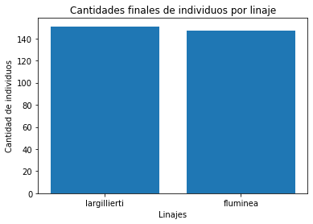

```python
## Declaramos valores para el eje x
eje_x = cantidades_finales.index

## Declaramos valores para el eje y
eje_y = cantidades_finales.Linaje

plt.figure()    #Figura. Puede incluirse el tamaño con figsize
plt.bar(eje_x, eje_y)          #El gráfico
plt.title('Cantidades finales de individuos por linaje')      #El título
ax = plt.subplot()                   #Axis
ax.set_xticks(eje_x)             #Eje x
ax.set_xticklabels(eje_x)        #Etiquetas del eje x
ax.set_xlabel('Linajes')  #Nombre del eje x
ax.set_ylabel('Cantidad de individuos')  #Nombre del eje y
```

# Glosario de variables

- **proy**: dataset con todos los datos de los que se parte.
- **cantidades**: cuenta de individuos por linaje contando a los indeterminados.
- **cantidades_finales**: cuenta final de individuos por linaje sin indeterminados.
- **eje_x** y **eje_y**: se utilizan 2 veces para graficar las cantidades iniciales y finales.
- **proysinindet**: dataframe original con el filtro de los que **NO** son indeterminados.
- **data**: contiene los registros de **proysinindet** sin el registro con un campo faltante.
- **x_chequeo**: contiene los registros de **data** que vamos a utilizar para probar los modelos, sin los campos que no se utilizan. Son los parámetros conocidos, las "x".
- **y_chequeo**: el dato conocido a predecir para probar los distintos modelos, la "y". En este caso, el "Linaje".
- **xtrain**, **xtest**, **ytrain**, **ytest**: son las x e y de prueba y entrenamiento del modelo. En nuestro caso con el random_state=42 y partiendo los datos en 80% para entrenamiento y 20% para chequeo.
- **lr**, **dtc**, **rfc**, **knn**: Son los modelos a evaluar, Regresión logística, Árbol de Decisión, Random Forest y K vecinos.
- **lr2**, *lr3: Distintos solver de Regresión Logística.
- **X**: copia de **x_chequeo** para utilizar en el modelo ya elegido.
- **y**: copia de **y_chequeo** para utilizar en el modelo ya elegido.
- **param_grid**: listado de Hyperparámetros para probar en nuestro modelo.
- **CV_rfc**: modelo elegido con los mejores hyperparámetros.
- **scores**: resultados de la mejora de los hyperparámetros.
- **model**: copia de **CV_rfc** para hacer mas fácil el llamado posterior al modelo elegido.
- **test_pred**: las "y" predichas por nuestro modelo para utilizar en las métricas.
- **indeterminados**: dataframe original con el filtro de los que **SI** son indeterminados. Este df es modificado luego de correr el modelo reemplazando los indeterminados por los linajes obtenidos. Además son los datos que exportamos en excel para la entrega al cliente.
- **x_adeterminar**: contiene los registros de **indeterminados** que vamos a utilizar para usar nuestro modelo, sin los campos que no se utilizan. Son los parámetros conocidos, las "x".
- **y_determinada**: las "y" finales, predichas por nuestro modelo.
- **final**: dataset con todos los datos originales de los que se parte con los indeterminados reemplazados por los obtenidos del modelo utilizado.